# [MPDW] Tugas Praktikum 1

# Impor Data

```r
library("forecast")
library("graphics")
library("TTR")
library("TSA")
library("readxl")
library("ggplot2")
```

```r
data <- read_excel("D:\\SMT 5\\Metode Peramalan Deret Waktu\\Tugas\\Tugas Praktikum 1\\100 Gugus Data Kelompok.xlsx")
head(data)
```

```
## # A tibble: 6 × 2
##   Date       `Monorail _User`
##   <chr>                 <dbl>
## 1 2023-11-05            45456
## 2 2023-11-06            55950
## 3 2023-11-07            59216
## 4 2023-11-08            59150
## 5 2023-11-09            59143
## 6 2023-11-10            61061
```

# Eksplorasi Data

```r
View(data)
str(data)
```

```
## tibble [100 × 2] (S3: tbl_df/tbl/data.frame)
##  $ Date          : chr [1:100] "2023-11-05" "2023-11-06" "2023-11-07" "2023-11-08" ...
##  $ Monorail _User: num [1:100] 45456 55950 59216 59150 59143 ...
```

```r
dim(data)
```

```
## [1] 100   2
```

```r
data.ts <- ts(data$`Monorail _User`)
data.ts
```

```
## Time Series:
## Start = 1
## End = 100
## Frequency = 1
##   [1] 45456 55950 59216 59150 59143 61061 58189 65967 46834 55153 57107 56599
##  [13] 57383 46432 41568 55532 58940 62450 62398 62591 51628 46357 56140 59051
##  [25] 58403 59321 61845 52745 49677 57278 58059 59617 60404 67467 55417 55027
##  [37] 60232 58386 55103 55364 57597 50605 50449 58056 58686 59167 58541 60866
##  [49] 57465 68843 56232 55672 55830 57203 57407 53934 79585 51696 57332 56375
##  [61] 55223 57190 44585 39254 56278 56917 57709 59613 61195 48575 44741 56945
##  [73] 57168 57981 59204 59954 46208 42970 57633 59663 62053 41704 59550 47548
##  [85] 42535 59158 59925 63215 38708 59159 53502 46048 58095 59472 61496 58465
##  [97] 59148 68149 70687 50706
```

```r
summary(data.ts)
```

```
##    Min. 1st Qu.  Median    Mean 3rd Qu.    Max.
##   38708   54754   57436   56245   59359   79585
```

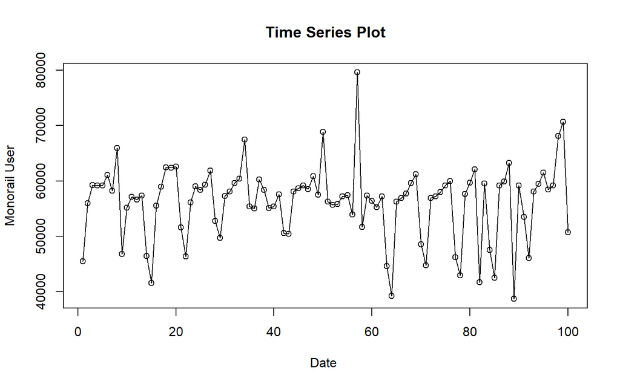

```r
ts.plot(data.ts, xlab="Date ", ylab="Monorail User",
        main = "Time Series Plot")
points(data.ts)
```

# Pembagian Data

```r
colnames(data)[2] <- "Monorail_User"

n <- nrow(data)
n_train <- floor(0.8 * n)

training_ma <- data[1:n_train, ]
testing_ma  <- data[(n_train+1):n, ]

training_ma$date <- as.Date(training_ma$Date)
testing_ma$date <- as.Date(testing_ma$Date)

train_ma.ts <- ts(training_ma$Monorail_User)
test_ma.ts  <- ts(testing_ma$Monorail_User)
```

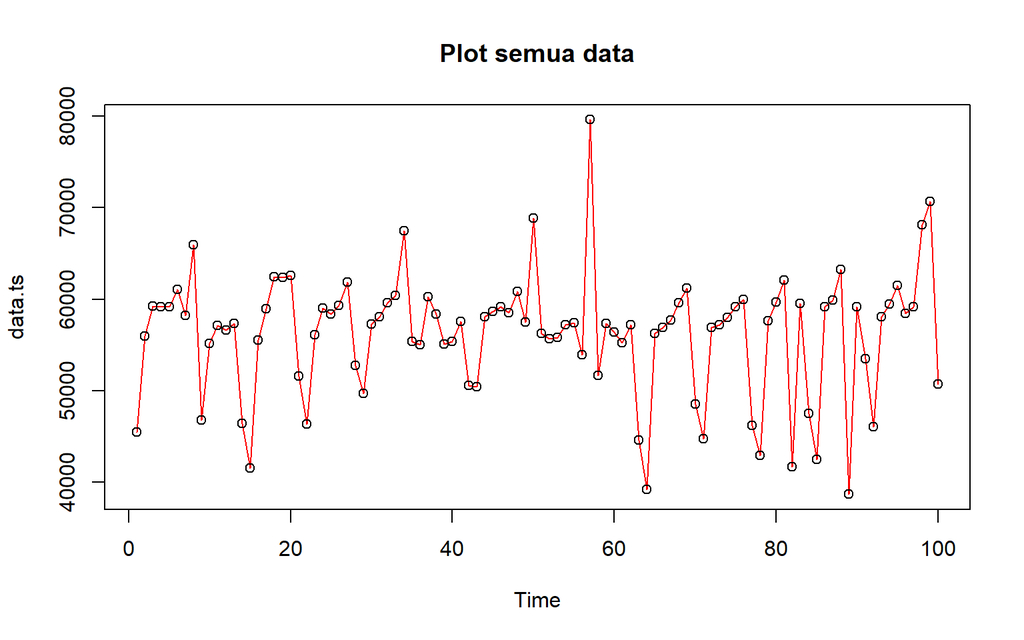

```r
plot(data.ts, col="red",main="Plot semua data")
points(data.ts)
```

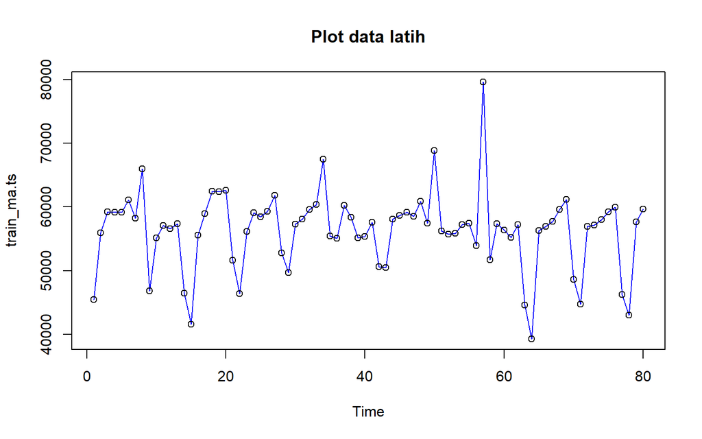

```r
plot(train_ma.ts, col="blue",main="Plot data latih")
points(train_ma.ts)
```

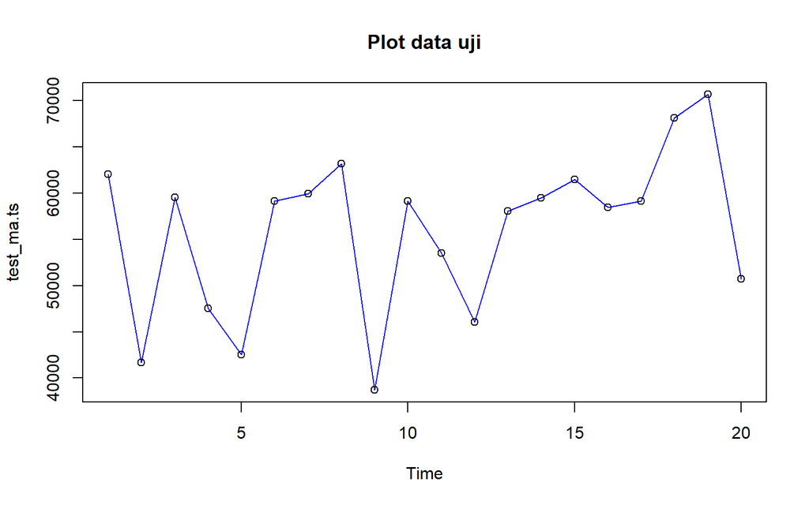

```r
plot(test_ma.ts, col="blue",main="Plot data uji")
points(test_ma.ts)
```

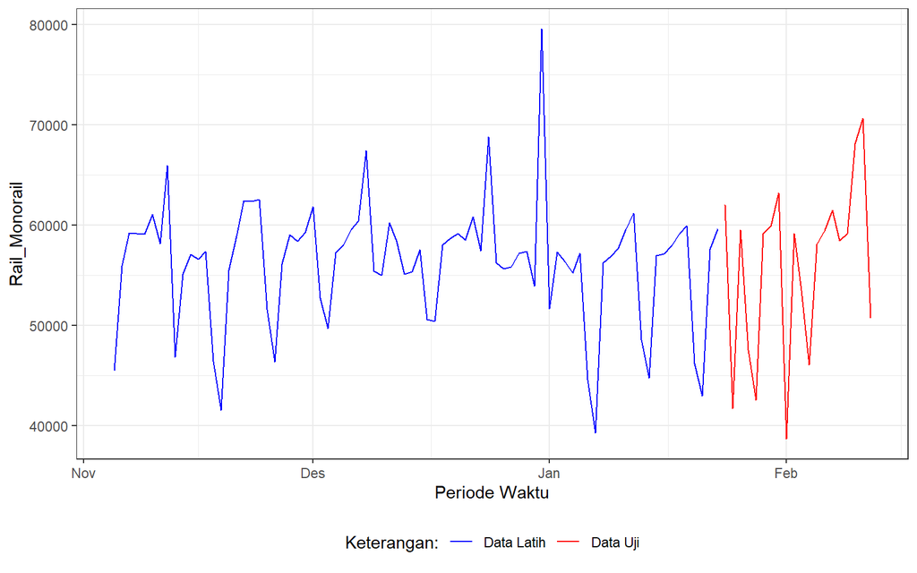

```r
ggplot() +
  geom_line(data = training_ma, aes(x = date, y = Monorail_User, col = "Data Latih")) +
  geom_line(data = testing_ma, aes(x = date, y = Monorail_User, col = "Data Uji")) +
  labs(x = "Periode Waktu", y = "Rail_Monorail", color = "Legend") +
   scale_colour_manual(name="Keterangan:", breaks = c("Data Latih", "Data Uji"),
                      values = c("blue", "red")) +
  theme_bw() + theme(legend.position = "bottom",
                     plot.caption = element_text(hjust=0.5, size=12))
```

# Single Moving Average

## Pemulusan

```r
data.sma<-SMA(train_ma.ts, n=4)
data.sma
```

```
## Time Series:
## Start = 1
## End = 80
## Frequency = 1
##  [1]       NA       NA       NA 54943.00 58364.75 59642.50 59385.75 61090.00
##  [9] 58012.75 56535.75 56265.25 53923.25 56560.50 54380.25 50495.50 50228.75
## [17] 50618.00 54622.50 59830.00 61594.75 59766.75 55743.50 54179.00 53294.00
## [25] 54987.75 58228.75 59655.00 58078.50 55897.00 55386.25 54439.75 56157.75
## [33] 58839.50 61386.75 60726.25 59578.75 59535.75 57265.50 57187.00 57271.25
## [41] 56612.50 54667.25 53503.75 54176.75 54449.00 56589.50 58612.50 59315.00
## [49] 59009.75 61428.75 60851.50 59553.00 59144.25 56234.25 56528.00 56093.50
## [57] 62032.25 60655.50 60636.75 61247.00 55156.50 56530.00 53343.25 49063.00
## [65] 49326.75 49258.50 52539.50 57629.25 58858.50 56773.00 53531.00 52864.00
## [73] 51857.25 54208.75 57824.50 58576.75 55836.75 52084.00 51691.25 51618.50
```

```r
data.ramal<-c(NA,data.sma)
data.ramal
```

```
##  [1]       NA       NA       NA       NA 54943.00 58364.75 59642.50 59385.75
##  [9] 61090.00 58012.75 56535.75 56265.25 53923.25 56560.50 54380.25 50495.50
## [17] 50228.75 50618.00 54622.50 59830.00 61594.75 59766.75 55743.50 54179.00
## [25] 53294.00 54987.75 58228.75 59655.00 58078.50 55897.00 55386.25 54439.75
## [33] 56157.75 58839.50 61386.75 60726.25 59578.75 59535.75 57265.50 57187.00
## [41] 57271.25 56612.50 54667.25 53503.75 54176.75 54449.00 56589.50 58612.50
## [49] 59315.00 59009.75 61428.75 60851.50 59553.00 59144.25 56234.25 56528.00
## [57] 56093.50 62032.25 60655.50 60636.75 61247.00 55156.50 56530.00 53343.25
## [65] 49063.00 49326.75 49258.50 52539.50 57629.25 58858.50 56773.00 53531.00
## [73] 52864.00 51857.25 54208.75 57824.50 58576.75 55836.75 52084.00 51691.25
## [81] 51618.50
```

```r
data.gab<-cbind(
  aktual=c(data.ts),
  pemulusan=c(data.sma,rep(NA,24)),
  ramalan=c(data.ramal,rep(data.ramal[length(data.ramal)],23)))
data.gab
```

```
##        aktual pemulusan  ramalan
##   [1,]  45456        NA       NA
##   [2,]  55950        NA       NA
##   [3,]  59216        NA       NA
##   [4,]  59150  54943.00       NA
##   [5,]  59143  58364.75 54943.00
##   [6,]  61061  59642.50 58364.75
##   [7,]  58189  59385.75 59642.50
##   [8,]  65967  61090.00 59385.75
##   [9,]  46834  58012.75 61090.00
##  [10,]  55153  56535.75 58012.75
##  [11,]  57107  56265.25 56535.75
##  [12,]  56599  53923.25 56265.25
##  [13,]  57383  56560.50 53923.25
##  [14,]  46432  54380.25 56560.50
```

[output cut: 90 more lines]

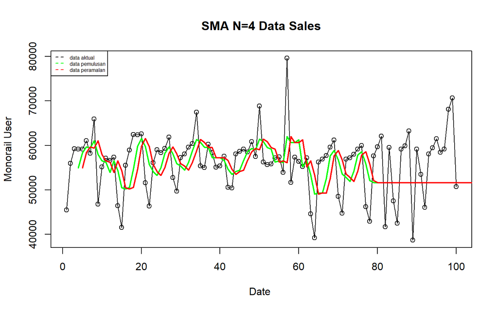

```r
ts.plot(data.ts, xlab="Date ", ylab="Monorail User", main= "SMA N=4 Data Sales")
points(data.ts)
lines(data.gab[,2],col="green",lwd=2)
lines(data.gab[,3],col="red",lwd=2)
legend("topleft",c("data aktual","data pemulusan","data peramalan"), lty=8, col=c("black","green","red"), cex=0.5)
```

## Evaluasi

### Data Latih

```r
error_train.sma = train_ma.ts-data.ramal[1:length(train_ma.ts)]

SSE_train.sma = sum(error_train.sma[5:length(train_ma.ts)]^2)
MSE_train.sma = mean(error_train.sma[5:length(train_ma.ts)]^2)
MAPE_train.sma = mean(abs((error_train.sma[5:length(train_ma.ts)]/train_ma.ts[5:length(train_ma.ts)])*100))

akurasi_train.sma <- matrix(c(SSE_train.sma, MSE_train.sma, MAPE_train.sma))
row.names(akurasi_train.sma)<- c("SSE", "MSE", "MAPE")
colnames(akurasi_train.sma) <- c("Akurasi m = 4")
akurasi_train.sma
```

```
##      Akurasi m = 4
## SSE   3.935531e+09
## MSE   5.178331e+07
## MAPE  1.081843e+01
```

### Data Uji

```r
error_test.sma = test_ma.ts-data.gab[81:100,3]

SSE_test.sma = sum(error_test.sma^2)
MSE_test.sma = mean(error_test.sma^2)
MAPE_test.sma = mean(abs((error_test.sma/test_ma.ts*100)))

akurasi_test.sma <- matrix(c(SSE_test.sma, MSE_test.sma, MAPE_test.sma))
row.names(akurasi_test.sma)<- c("SSE", "MSE", "MAPE")
colnames(akurasi_test.sma) <- c("Akurasi m = 4")
akurasi_test.sma
```

```
##      Akurasi m = 4
## SSE   1.830056e+09
## MSE   9.150280e+07
## MAPE  1.541900e+01
```

# Double Moving Average

## Pemulusan

```r
dma <- SMA(data.sma, n = 4)
At <- 2*data.sma - dma
Bt <- 2/(4-1)*(data.sma - dma)
data.dma<- At+Bt
data.ramal2<- c(NA, data.dma)

t = 1:20
f = c()

for (i in t) {
  f[i] = At[length(At)] + Bt[length(Bt)]*(i)
}

data.gab2 <- cbind(aktual = c(data.ts),
                   pemulusan1 = c(data.sma,rep(NA,20)),
                   pemulusan2 = c(dma, rep(NA,20)),
                   At = c(At, rep(NA,20)),
                   Bt = c(Bt,rep(NA,20)),
                   ramalan = c(data.ramal2, f[-1]))
data.gab2
```

```
##        aktual pemulusan1 pemulusan2       At          Bt  ramalan
##   [1,]  45456         NA         NA       NA          NA       NA
##   [2,]  55950         NA         NA       NA          NA       NA
##   [3,]  59216         NA         NA       NA          NA       NA
##   [4,]  59150   54943.00         NA       NA          NA       NA
##   [5,]  59143   58364.75         NA       NA          NA       NA
##   [6,]  61061   59642.50         NA       NA          NA       NA
##   [7,]  58189   59385.75   58084.00 60687.50   867.83333       NA
##   [8,]  65967   61090.00   59620.75 62559.25   979.50000 61555.33
##   [9,]  46834   58012.75   59532.75 56492.75 -1013.33333 63538.75
##  [10,]  55153   56535.75   58756.06 54315.44 -1480.20833 55479.42
##  [11,]  57107   56265.25   57975.94 54554.56 -1140.45833 52835.23
##  [12,]  56599   53923.25   56184.25 51662.25 -1507.33333 53414.10
##  [13,]  57383   56560.50   55821.19 57299.81   492.87500 50154.92
##  [14,]  46432   54380.25   55282.31 53478.19  -601.37500 57792.69
```

[output cut: 86 more lines]

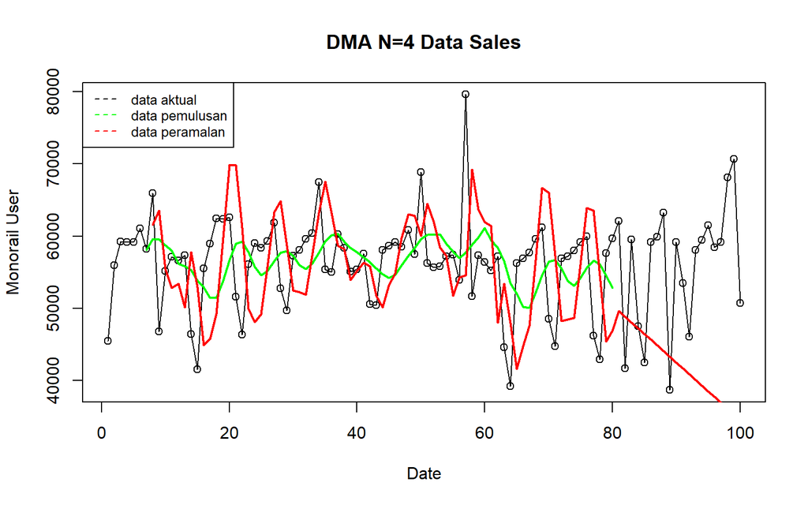

```r
ts.plot(data.ts, xlab="Date", ylab="Monorail User", main= "DMA N=4 Data Sales")
points(data.ts)
lines(data.gab2[,3],col="green",lwd=2)
lines(data.gab2[,6],col="red",lwd=2)
legend("topleft",c("data aktual","data pemulusan","data peramalan"), lty=8, col=c("black","green","red"), cex=0.8)
```

## Evaluasi

### Data Latih

```r
error_train.dma = train_ma.ts-data.ramal2[1:length(train_ma.ts)]

SSE_train.dma = sum(error_train.dma[8:length(train_ma.ts)]^2)
MSE_train.dma = mean(error_train.dma[8:length(train_ma.ts)]^2)
MAPE_train.dma = mean(abs((error_train.dma[8:length(train_ma.ts)]/train_ma.ts[8:length(train_ma.ts)])*100))

akurasi_train.dma <- matrix(c(SSE_train.dma, MSE_train.dma, MAPE_train.dma))
row.names(akurasi_train.dma)<- c("SSE", "MSE", "MAPE")
colnames(akurasi_train.dma) <- c("Akurasi m = 4")
akurasi_train.dma
```

```
##      Akurasi m = 4
## SSE   6.201974e+09
## MSE   8.495855e+07
## MAPE  1.401539e+01
```

### Data Uji

```r
error_test.dma = test_ma.ts-data.gab2[81:100,6]
SSE_test.dma = sum(error_test.dma^2)
MSE_test.dma = mean(error_test.dma^2)
MAPE_test.dma = mean(abs((error_test.dma/test_ma.ts*100)))

akurasi_test.dma <- matrix(c(SSE_test.dma, MSE_test.dma, MAPE_test.dma))
row.names(akurasi_test.dma)<- c("SSE", "MSE", "MAPE")
colnames(akurasi_test.dma) <- c("Akurasi m = 4")
akurasi_test.dma
```

```
##      Akurasi m = 4
## SSE   6.299531e+09
## MSE   3.149766e+08
## MAPE  2.607295e+01
```

# Single Exponential Smoothing

## Manual

### Pemulusan

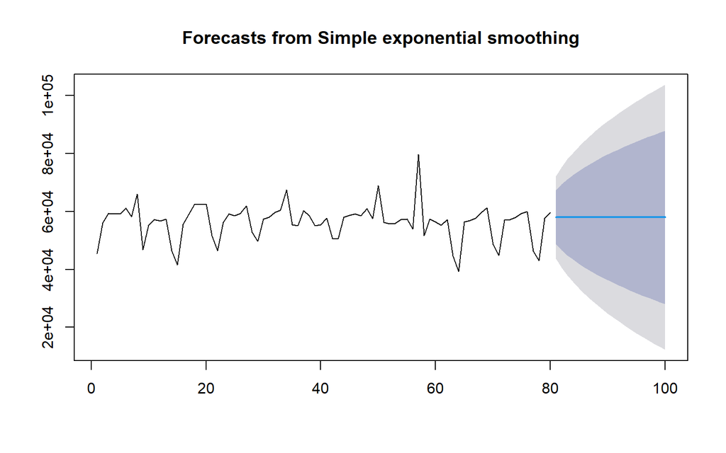

```r
ses.1 <- ses(train_ma.ts, h = 20, alpha = 0.7)
plot(ses.1)
```

```r
ses.1
```

```
##     Point Forecast    Lo 80    Hi 80    Lo 95     Hi 95
##  81          57930 48624.40 67235.59 43698.31  72161.68
##  82          57930 46571.07 69288.92 40558.01  75301.98
##  83          57930 44835.86 71024.13 37904.24  77955.75
##  84          57930 43305.10 72554.89 35563.15  80296.84
##  85          57930 41920.04 73939.95 33444.88  82415.11
##  86          57930 40645.62 75214.37 31495.82  84364.17
##  87          57930 39458.91 76401.08 29680.91  86179.08
##  88          57930 38343.98 77516.01 27975.77  87884.22
##  89          57930 37289.18 78570.81 26362.60  89497.39
##  90          57930 36285.73 79574.26 24827.95  91032.04
##  91          57930 35326.78 80533.21 23361.36  92498.63
##  92          57930 34406.89 81453.10 21954.51  93905.48
##  93          57930 33521.64 82338.35 20600.64  95259.35
##  94          57930 32667.40 83192.59 19294.19  96565.80
##  95          57930 31841.11 84018.88 18030.49  97829.50
##  96          57930 31040.20 84819.79 16805.61  99054.39
##  97          57930 30262.47 85597.52 15616.16 100243.83
##  98          57930 29506.00 86353.99 14459.25 101400.74
##  99          57930 28769.16 87090.83 13332.35 102527.65
## 100          57930 28050.48 87809.51 12233.22 103626.77
```

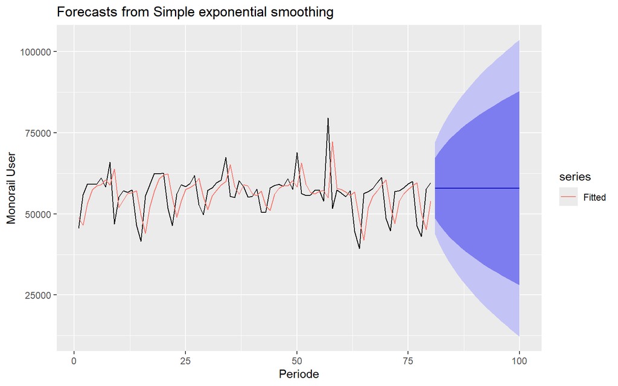

```r
autoplot(ses.1) +
  autolayer(fitted(ses.1), series="Fitted") +
  ylab("Monorail User") + xlab("Periode")
```

### Evaluasi

```r
accuracy(ses.1, testing_ma$Monorail_User)
```

```
##                      ME     RMSE      MAE        MPE      MAPE     MASE
## Training set   161.3552 7169.856 5299.039 -0.7988847  9.779147 1.039458
## Test set     -1963.8456 8743.994 6512.051 -6.2510944 13.241068 1.277402
##                    ACF1
## Training set -0.1271942
## Test set             NA
```

## Holt-Winter

### Pemulusan

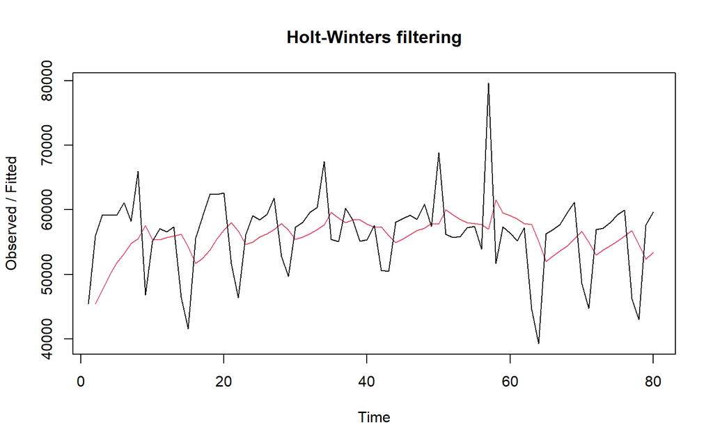

```r
seshw<- HoltWinters(train_ma.ts, gamma = FALSE, beta = FALSE, alpha = 0.2)
plot(seshw)
```

```r
ramalanhw<- forecast(seshw, h=20)
ramalanhw
```

```
##     Point Forecast    Lo 80    Hi 80    Lo 95    Hi 95
##  81       54633.66 45901.37 63365.94 41278.78 67988.53
##  82       54633.66 45728.44 63538.87 41014.30 68253.01
##  83       54633.66 45558.80 63708.51 40754.86 68512.45
##  84       54633.66 45392.28 63875.04 40500.19 68767.13
##  85       54633.66 45228.70 64038.61 40250.02 69017.30
##  86       54633.66 45067.92 64199.39 40004.12 69263.19
##  87       54633.66 44909.80 64357.52 39762.30 69505.02
##  88       54633.66 44754.21 64513.11 39524.34 69742.97
##  89       54633.66 44601.03 64666.29 39290.07 69977.24
##  90       54633.66 44450.15 64817.16 39059.33 70207.98
##  91       54633.66 44301.48 64965.83 38831.96 70435.36
##  92       54633.66 44154.92 65112.40 38607.81 70659.51
##  93       54633.66 44010.38 65256.94 38386.75 70880.56
##  94       54633.66 43867.77 65399.54 38168.66 71098.65
##  95       54633.66 43727.04 65540.28 37953.42 71313.89
##  96       54633.66 43588.10 65679.22 37740.93 71526.39
##  97       54633.66 43450.88 65816.44 37531.07 71736.24
##  98       54633.66 43315.32 65951.99 37323.76 71943.55
##  99       54633.66 43181.37 66085.94 37118.90 72148.41
## 100       54633.66 43048.97 66218.34 36916.41 72350.90
```

### Evaluasi

```r
accuracy(ramalanhw, testing_ma$Monorail_User)
```

```
##                     ME     RMSE      MAE        MPE     MAPE     MASE      ACF1
## Training set  580.8644 6795.445 5451.217 -0.2345707 10.02672 1.069309 0.1983748
## Test set     1332.4932 8624.168 7500.953 -0.2051833 14.19469 1.471385        NA
```

## SES Optimum

### Pemulusan

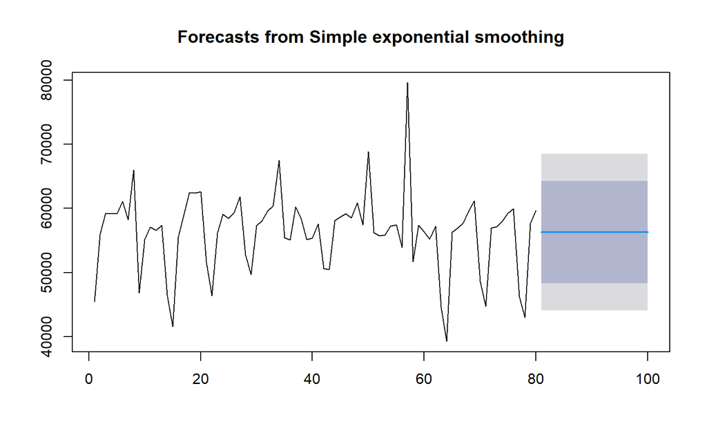

```r
ses.opt <- ses(train_ma.ts, h = 20, alpha = NULL)
plot(ses.opt)
```

```r
ses.opt
```

```
##     Point Forecast    Lo 80    Hi 80    Lo 95    Hi 95
##  81       56268.41 48289.46 64247.36 44065.66 68471.16
##  82       56268.41 48289.46 64247.36 44065.66 68471.16
##  83       56268.41 48289.46 64247.36 44065.66 68471.16
##  84       56268.41 48289.46 64247.36 44065.66 68471.16
##  85       56268.41 48289.46 64247.36 44065.66 68471.16
##  86       56268.41 48289.46 64247.36 44065.66 68471.16
##  87       56268.41 48289.46 64247.36 44065.66 68471.16
##  88       56268.41 48289.46 64247.36 44065.66 68471.16
##  89       56268.41 48289.46 64247.36 44065.66 68471.16
##  90       56268.41 48289.46 64247.36 44065.66 68471.16
##  91       56268.41 48289.46 64247.36 44065.66 68471.16
##  92       56268.41 48289.46 64247.36 44065.66 68471.16
##  93       56268.41 48289.46 64247.36 44065.66 68471.16
##  94       56268.41 48289.46 64247.36 44065.66 68471.16
##  95       56268.41 48289.46 64247.36 44065.66 68471.16
##  96       56268.41 48289.46 64247.36 44065.66 68471.16
##  97       56268.41 48289.46 64247.36 44065.66 68471.16
##  98       56268.41 48289.46 64247.36 44065.66 68471.16
##  99       56268.41 48289.46 64247.36 44065.66 68471.16
## 100       56268.41 48289.46 64247.36 44065.66 68471.16
```

### Evaluasi

```r
accuracy(ses.opt, testing_ma$Monorail_User)
```

```
##                      ME     RMSE      MAE       MPE      MAPE     MASE
## Training set   45.69289 6147.690 4238.954 -1.195915  7.957643 0.831512
## Test set     -302.25906 8525.966 7010.527 -3.203530 13.721759 1.375183
##                   ACF1
## Training set 0.1879721
## Test set            NA
```

# Double Exponential Smoothing

## Holt-Winters

### Pemulusan

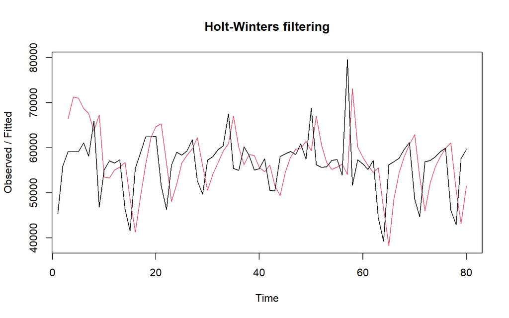

```r
des<- HoltWinters(train_ma.ts, gamma = FALSE, beta = 0.3, alpha = 0.6)
plot(des)
```

```r
ramalandes<- forecast(des, h=20)
ramalandes
```

```
##     Point Forecast      Lo 80     Hi 80       Lo 95     Hi 95
##  81       57594.08  46924.436  68263.72   41276.269  73911.89
##  82       58767.56  45236.029  72299.09   38072.870  79462.25
##  83       59941.04  42969.934  76912.14   33985.973  85896.10
##  84       61114.52  40234.708  81994.33   29181.603  93047.43
##  85       62288.00  37102.218  87473.78   23769.672 100806.33
##  86       63461.48  33620.796  93302.16   17824.092 109098.87
##  87       64634.96  29824.444  99445.48   11396.870 117873.05
##  88       65808.44  25738.285 105878.59    4526.427 127090.45
##  89       66981.92  21381.711 112582.13   -2757.582 136721.42
##  90       68155.40  16770.243 119540.56  -10431.416 146742.22
##  91       69328.88  11916.685 126741.07  -18475.495 157133.25
##  92       70502.36   6831.856 134172.86  -26873.273 167877.99
##  93       71675.84   1525.072 141826.61  -35610.502 178962.18
##  94       72849.32  -3995.515 149694.16  -44674.714 190373.35
##  95       74022.80  -9722.678 157768.28  -54054.857 202100.46
##  96       75196.28 -15649.944 166042.51  -63741.031 214133.59
##  97       76369.76 -21771.463 174510.99  -73724.289 226463.81
##  98       77543.24 -28081.908 183168.39  -83996.484 239082.97
##  99       78716.72 -34576.393 192009.84  -94550.146 251983.59
## 100       79890.20 -41250.421 201030.82 -105378.392 265158.79
```

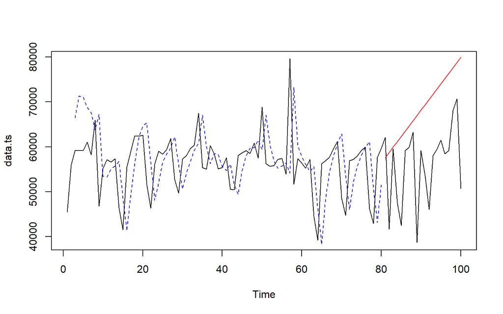

```r
plot(data.ts)
lines(des$fitted[,1], lty=2, col="blue")
lines(ramalandes$mean, col="red")
```

### Evaluasi

#### Data Latih

```r
ssedes.train<-des$SSE
msedes.train<-ssedes.train/length(train_ma.ts)
sisaandes<-ramalandes$residuals
head(sisaandes)
```

```
## Time Series:
## Start = 1
## End = 6
## Frequency = 1
## [1]        NA        NA  -7228.00 -12150.16 -11873.00  -7699.99
```

```r
mapedes.train <- sum(abs(sisaandes[3:length(train_ma.ts)]/train_ma.ts[3:length(train_ma.ts)])
                      *100)/length(train_ma.ts)

akurasides <- matrix(c(ssedes.train,msedes.train,mapedes.train))
row.names(akurasides)<- c("SSE", "MSE", "MAPE")
colnames(akurasides) <- c("Akurasi lamda=0.6 dan gamma=0.3")
akurasides
```

```
##      Akurasi lamda=0.6 dan gamma=0.3
## SSE                     5.371634e+09
## MSE                     6.714542e+07
## MAPE                    1.120352e+01
```

#### Data Uji

```r
selisihdes<-ramalandes$mean-testing_ma$Monorail_User
selisihdes
```

```
## Time Series:
## Start = 81
## End = 100
## Frequency = 1
##  [1] -4458.9214 17063.5587   391.0389 13566.5190 19752.9992  4303.4793
##  [7]  4709.9594  2593.4396 28273.9197  8996.3998 15826.8800 24454.3601
## [13] 13580.8403 13377.3204 12526.8005 16731.2807 17221.7608  9394.2410
## [19]  8029.7211 29184.2012
```

```r
SSEtestingdes<-sum(selisihdes^2)
MSEtestingdes<-SSEtestingdes/length(testing_ma$Monorail_User)
MAPEtestingdes<-sum(abs(selisihdes/testing_ma$Monorail_User)*100)/length(testing_ma$Monorail_User)

akurasidestest <- matrix(c(SSEtestingdes,MSEtestingdes,MAPEtestingdes))
row.names(akurasidestest)<- c("SSE", "MSE", "MAPE")
colnames(akurasidestest) <- c("Akurasi lamda=0.6 dan gamma=0.3")
akurasidestest
```

```
##      Akurasi lamda=0.6 dan gamma=0.3
## SSE                     4.763000e+09
## MSE                     2.381500e+08
## MAPE                    2.602904e+01
```

## DES Optimum

### Pemulusan

```r
des.opt<- HoltWinters(train_ma.ts, gamma = FALSE)
des.opt
```

```
## Holt-Winters exponential smoothing with trend and without seasonal component.
##
## Call:
## HoltWinters(x = train_ma.ts, gamma = FALSE)
##
## Smoothing parameters:
##  alpha: 0.6648376
##  beta : 0.1912281
##  gamma: FALSE
##
## Coefficients:
##         [,1]
## a 57351.6754
## b   771.7823
```

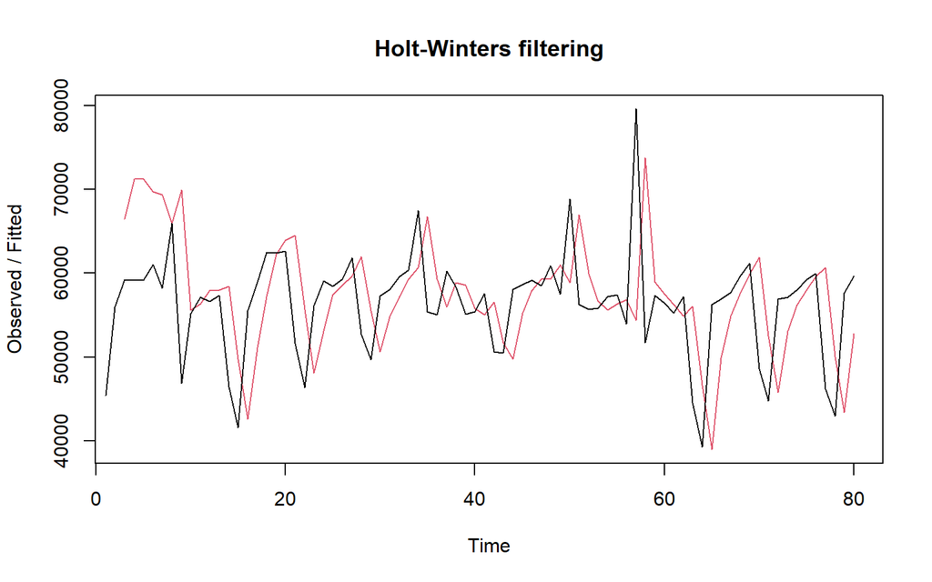

```r
plot(des.opt)
```

```r
ramalandesopt<- forecast(des.opt, h=20)
ramalandesopt
```

```
##     Point Forecast      Lo 80     Hi 80      Lo 95     Hi 95
##  81       58123.46  47592.890  68654.03  42018.345  74228.57
##  82       58895.24  45462.175  72328.31  38351.139  79439.34
##  83       59667.02  43110.295  76223.75  34345.693  84988.35
##  84       60438.80  40551.332  80326.28  30023.539  90854.07
##  85       61210.59  37797.104  84624.07  25402.755  97018.42
##  86       61982.37  34857.679  89107.06  20498.735 103466.00
##  87       62754.15  31741.745  93766.56  15324.769 110183.53
##  88       63525.93  28456.894  98594.97   9892.466 117159.40
##  89       64297.72  25009.826 103585.61   4212.074 124383.36
##  90       65069.50  21406.512 108732.49  -1707.277 131846.27
##  91       65841.28  17652.313 114030.25  -7857.386 139539.95
##  92       66613.06  13752.076 119474.05 -14230.840 147456.97
##  93       67384.85   9710.215 125059.48 -20820.891 155590.58
##  94       68156.63   5530.764 130782.49 -27621.365 163934.62
##  95       68928.41   1217.436 136639.38 -34626.589 172483.41
##  96       69700.19  -3226.343 142626.73 -41831.319 181231.70
##  97       70471.98  -7797.395 148741.34 -49230.696 190174.65
##  98       71243.76 -12492.763 154980.28 -56820.200 199307.71
##  99       72015.54 -17309.688 161340.77 -64595.607 208626.69
## 100       72787.32 -22245.584 167820.23 -72552.966 218127.61
```

### Evaluasi

#### Data Latih

```r
ssedesopt.train<-des.opt$SSE
msedesopt.train<-ssedesopt.train/length(train_ma.ts)
sisaandesopt<-ramalandesopt$residuals
head(sisaandesopt)
```

```
## Time Series:
## Start = 1
## End = 6
## Frequency = 1
## [1]         NA         NA  -7228.000 -12063.617 -12091.619  -8638.728
```

```r
mapedesopt.train <- sum(abs(sisaandesopt[3:length(train_ma.ts)]/train_ma.ts[3:length(train_ma.ts)])
                      *100)/length(train_ma.ts)

akurasidesopt <- matrix(c(ssedesopt.train,msedesopt.train,mapedesopt.train))
row.names(akurasidesopt)<- c("SSE", "MSE", "MAPE")
akurasidesopt
```

```
##              [,1]
## SSE  5.274000e+09
## MSE  6.592500e+07
## MAPE 1.080114e+01
```

#### Data Uji

```r
selisihdesopt<-ramalandesopt$mean-testing_ma$Monorail_User
selisihdesopt
```

```
## Time Series:
## Start = 81
## End = 100
## Frequency = 1
##  [1] -3929.5423 17191.2400   117.0224 12890.8047 18675.5870  2824.3694
##  [7]  2829.1517   310.9341 25589.7164  5910.4987 12339.2811 20565.0634
## [13]  9289.8457  8684.6281  7432.4104 11235.1928 11323.9751  3094.7574
## [19]  1328.5398 22081.3221
```

```r
SSEtestingdesopt<-sum(selisihdesopt^2)
MSEtestingdesopt<-SSEtestingdesopt/length(testing_ma$Monorail_User)
MAPEtestingdesopt<-sum(abs(selisihdesopt/testing_ma$Monorail_User)*100)/length(testing_ma$Monorail_User)

akurasidestestopt <- matrix(c(SSEtestingdesopt,MSEtestingdesopt,MAPEtestingdesopt))
row.names(akurasidestestopt)<- c("SSE", "MSE", "MAPE")
akurasidestestopt
```

```
##              [,1]
## SSE  3.077323e+09
## MSE  1.538662e+08
## MAPE 2.017949e+01
```

# Evaluasi Metrik

## Ringkasan MAPE

- **Single Moving Average (m=4):** Menghasilkan nilai MAPE sebesar 10,82% pada data latih dan 15,42% pada data uji
- **Double Moving Average (m=4):** Menghasilkan nilai MAPE sebesar 14,02% pada data latih dan 26,07% pada data uji
- Single Exponential Smoothing:  
  SES Manual (α=0,7): Menghasilkan nilai MAPE sebesar 9,78% pada data latih dan 13,24% pada data uji  
  **SES Holt-Winter (α=0,2):** Menghasilkan nilai MAPE sebesar 10,03% pada data latih dan 14,19% pada data uji  
  **SES Optimum:** Menghasilkan nilai MAPE sebesar 7,96% pada data latih dan 13,72% pada data uji
- Double Exponential Smoothing:  
  DES Holt-Winter (α=0,6 ; β=0,3): Menghasilkan nilai MAPE sebesar 11,20% pada data latih dan 26,03% pada data uji  
  **DES Optimum:** Menghasilkan nilai MAPE sebesar 10,80% pada data latih dan 20,18% pada data uji

## Kesimpulan

Berdasarkan hasil evaluasi, **Single Exponential Smoothing (SES) dengan parameter** $\alpha = 0,7$ merupakan metode terbaik untuk memodelkan pergerakan pengguna *monorail*. Hal ini dikarenakan metode tersebut menghasilkan tingkat kesalahan peramalan (MAPE) paling kecil pada **data uji** dibandingkan metode lainnya, yakni sebesar 13,24%.